# Félév végi beadandó

Szalka Áron

2020 01 05

# készítette: Szalka Áron

A félév végi beadandómban a Magyarországi moziforgalom 2014-es adatait elemzem R segítségével. Ehhez a Nemzeti Filmiroda honalpjáról töltöttem le a “2014-ben vetített (premier és nem premier) filmek összesített forgalmi adatai” című excell táblát. Innen lehet letölteni: http://nmhh.hu/nemzeti-filmiroda/mozgokep-statisztika.

```r
library(ggplot2)
library(data.table)
library(readxl)
library(car)
library(magrittr)
library(dplyr)
setwd("G:/Egyetem/R/Beadando")
data <- read_excel("filmek 2014.xlsx",
                               col_types = c("text", "text", "text",
                                                   "date", "numeric", "numeric", "numeric",
                                                   "numeric", "numeric", "numeric",
                                                   "numeric", "numeric", "text", "numeric",
                                                   "numeric", "text"), n_max = 555)
```

# Adat tisztítgatás, rendezés, új oszlopok

Kezdetben szükség vot az adatok letisztítására, illetve néhány új oszlop bevezetésére. Az átláthatóság kedvéért a több országhoz tartozó filmek esetében az elsőnek beírtat vettem alapul, mert a sorrendjük nem mindig volt azonos, amiből valószíűsíthető, hogy az első a legfontosabb, de erre vonatkozó információt nem találtam. A filmek lehetséges származási országáit 4 csoportba osztottam : USA, Magyarország, Európa (Magyarország nélkül) és a maradék országok csoportjára. Minden filhez kiszámoltam továbbá az átlagos jegy árát, illetve hogy volt-e 3D formátumban vetítve. Néhány egyértelműen hibás adatot felülírtam az értelemszerűség szerint.

```r
#adatok tisztítása
data$`Bemutató időpontja` <- as.Date(data$`Bemutató időpontja`)
data$Gyartoorszagrovid <- stringr::str_extract(data$`Gyártó ország (ISO-kóddal)`, "^.{2}")
data$Gyartoorszagrovid <- as.factor(data$Gyartoorszagrovid)


#átlagos jegyár kiszámítása
data$atlagosjegyar <- data$`Pénztári jegybev.(Ft) (bruttó)`/data$`Látogatók száma (fő)`

#országcsoportok különválasztása
data$Orszagcsoport <- data$Gyartoorszagrovid
data$Orszagcsoport <- "Egyéb"
data$Orszagcsoport[data$Gyartoorszagrovid == "US"] <- "USA"
data$Orszagcsoport[data$Gyartoorszagrovid == "HU"] <- "Magyarország"
data$Orszagcsoport[data$Gyartoorszagrovid %in% c("FR", "IT", "CZ", "ES", "PL", "BA", "GB", "BE", "DE", "PT", "NO", "RO", "RU", "CH", "SE", "DK", "LT", "FI", "EE", "AU", "IS", "NL", "IE")] <- "Európa"
data$Orszagcsoport <- as.factor(data$Orszagcsoport)

#egyéb kis adathibák kijavítása
data$`Forgalmazó` <- as.factor(data$`Forgalmazó`)
data$`Forgalmazó`[data$`Forgalmazó` == "Cirko Film Kft."] <- "Cirkofilm  Kft."
data$`Forgalmazó`[data$`Forgalmazó` == "Forum Hungary FilmforgalmazóKft."] <- "Forum Hungary Filmforgalmazó Kft."
data$`Induló összes digitális kópiaszám`[data$`Film címe` == "Lego kaland, A"] <- 58
data$`Induló összes kópiaszám`[data$`Film címe` == "Lego kaland, A"] <- 58

#van-e 3D-s verzió
data$`3D-s verzió előadásszám (IMAX-el)`[is.na(data$`3D-s verzió előadásszám (IMAX-el)`)] <- 0
data$vane3d <- data$`3D-s verzió előadásszám (IMAX-el)` > 0
```

# Különböző szűrések

Második lépésként az adataimat különböző képpen megszűrtem, de a továbbiakban is használtam a teljes adatot is. A szűrés több részből állt: a legnézettebb 250 és a legnézettebb 40 film kiszűrésével kezdődött. Az 555 filmből álló adat közül a legnézettebb 250 re azért volt szükség, mert a maradék nagyon alacsony nézőszámmalrendelkezik csak, ami az 1000-et sem haladja meg, és bizonyos számolásoknál torzíthatsák a mintát. Ezen kívül kiszűrtem a legkisebb forgalmazókat is, amely filmforgalmazók maximum 3 filmet forgalmaztak egy éven, mert a későbbiekben a filmforgalmazók össszehasonlítása során torzíthatják az eredményeket. Végül a 2014 előtt bemutatott, de 2014-ben is játszott filmeket is kiszűrtem, mert az ő esetükben különesen torz lehet pl a nézőszám vagy az előadásszám a többihez képest.

```r
#itt kezdődik a szűrés


#csak a lényeges filmek, a mikrovetítések kiszűrése
topfilms <- data[with(data,order(-data$`Látogatók száma (fő)`)),][1:250,]
top40 <- topfilms[with(topfilms,order(-topfilms$`Látogatók száma (fő)`)),][1:40,]

#az olyan filmek kiszűrése, amelyeknek a forgalmazója jelentéktelen
ritka_forgalmazok <- names(table(topfilms$`Forgalmazó`))[table(topfilms$`Forgalmazó`) < 4]
topforgalmazok <- subset(topfilms,!topfilms$`Forgalmazó` %in% ritka_forgalmazok)

#a 2014 előtti filmek kiszűrése
top14 <- subset(topforgalmazok, !topforgalmazok$`Bemutató időpontja` < as.Date("2014-01-01"))
```

# Saját theme beállítása

```r
# saját theme beállítása hogy az ábrák jól nézzenek ki
mytheme <- function (base_size = 11, base_family = "", base_line_size = base_size/22,
                     base_rect_size = base_size/22)
{
  theme_bw(base_size = base_size, base_family = base_family,
           base_line_size = base_line_size, base_rect_size = base_rect_size) %+replace%
    theme(panel.border = element_blank(), panel.grid.major = element_blank(),
          panel.grid.minor = element_blank(), axis.line = element_line(colour = "black",
                                                                       size = rel(1)), legend.key = element_blank(),
          strip.background = element_rect(fill = "white",
                                          colour = "black", size = rel(2)), complete = TRUE,
          plot.title = element_text(hjust = 0.5, size = 14))
}
```

# Mikori filmeket játszottak?

Az első kérdés, amit megnéztem, az volt, hogy mikori filmeket vetítettek 2014-ben. Az ábrákon jól látszik, hogy szinte csak 2010 óta megjelent filmeket vetítettek a magyar mozik, azon belül viszont egyészen 2010-ig egészen sűrűnek mondható az eloszlásuk. Ennél is szembetűnőbb, hogy azok a filmek, amiket a mozik sokszor vetítettek gyakorlatilag kivétel nélkül 2014-ben vagy 2013 legvégén megjelent filmek, és ez nem meglepő mert a mozik szinte mindig frss filmeket játszanak.

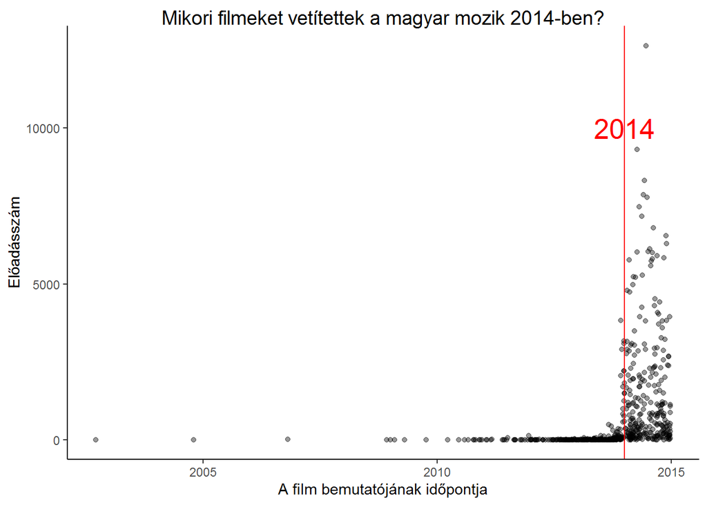

```r
#itt kezdődnek az ábrák

#Mikori filmeket vetítettek a mozik? Ország szerint

ggplot(data, aes(x = data$`Bemutató időpontja`, y = data$`Előadás-szám`)) +
                    geom_point(alpha = 0.4) +
                    geom_vline(xintercept = as.Date("2014-01-01"),color = "red") +
                    annotate("text", x = as.Date("2014-01-01"), y = 10000, label= "2014", color = "red", size = 7) +
                    ggtitle(label = "Mikori filmeket vetítettek a magyar mozik 2014-ben?",) +
                    xlab(label = "A film bemutatójának időpontja") +
                    ylab(label = "Előadásszám") +
                    mytheme()
```

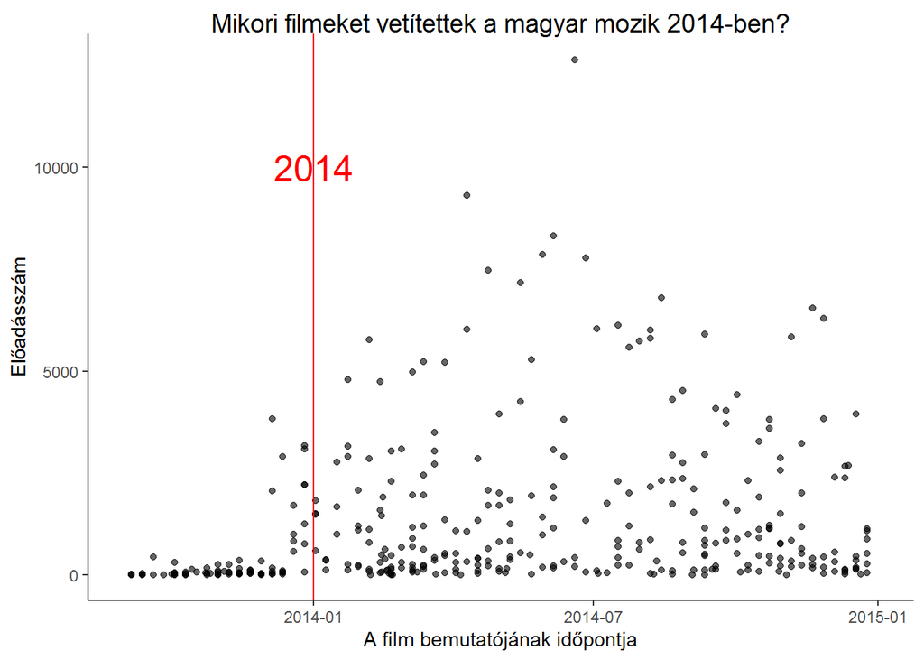

```r
ggplot(data, aes(x = data$`Bemutató időpontja`, y = data$`Előadás-szám`)) +
                    geom_point(alpha = 0.6) +
                    geom_vline(xintercept = as.Date("2014-01-01"),color = "red") +
                    scale_x_date(limits = c(as.Date("2013-09-01"), as.Date("2014-12-31"))) +
                    annotate("text", x = as.Date("2014-01-01"), y = 10000, label= "2014", color = "red", size = 7) +
                    ggtitle(label = "Mikori filmeket vetítettek a magyar mozik 2014-ben?",) +
                    xlab(label = "A film bemutatójának időpontja") +
                    ylab(label = "Előadásszám") +
                    mytheme()
```

# Mennyivel volt drágább a 3D?

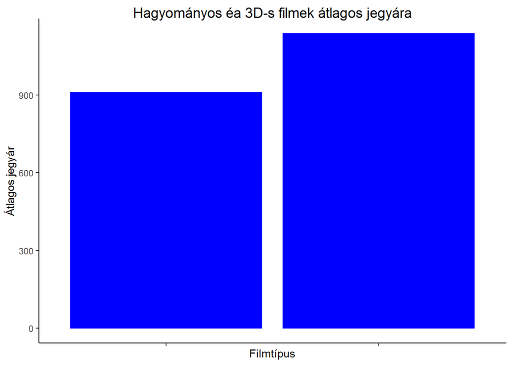

```r
ggplot(data, aes(x = data$vane3d, y = data$atlagosjegyar)) +
  stat_summary(fun.y = mean, geom ="bar", color = "blue", fill = "blue") +
  ggtitle(label = "Hagyományos éa 3D-s filmek átlagos jegyára",) +
  xlab(label = "Filmtípus") +
  ylab(label = "Átlagos jegyár") +
  mytheme() +
  theme(axis.text.x = element_blank())
```

# Amerikai dominancia

Az előzőnél talán kevésbe egyértelmű kérdés, hogy a honnan származnak a magyar mozikban játszott filmek. Az önmagában nem meglepő, hogy az Egyesült Államokból érdező filmek elég dominánsak a magyar piacon is, de ehhez képest is kimagasló az arányuk. Az első ábrán a 2014-ben legnépszerűbb 40 film látható a nézők száma alapján. Ebből kiderül, hogy a Magyarországon 2014-ben legnézettebb 40 filmbe mindössze 2 db nem az USÁ-ból származó film került be, azok is csak a 30. hely környékére. Ha a nézőszámot az összes film országcsoportjai szerint bontjuk fel, a második ábrát kapjuk, ahol szintén szembetűnő, hogy szinte minden eladott mozijegyet amerikai filmre váltottak meg. Ez látható a harmadik ábrán is, csak egy kördiagramon. Pedig választék lett volna más filmekre is, legalábbis Budapesten: a negyedik ábrán látható, hogy a bemutatott filmeknek a fele sem volt egyébként amerikai.

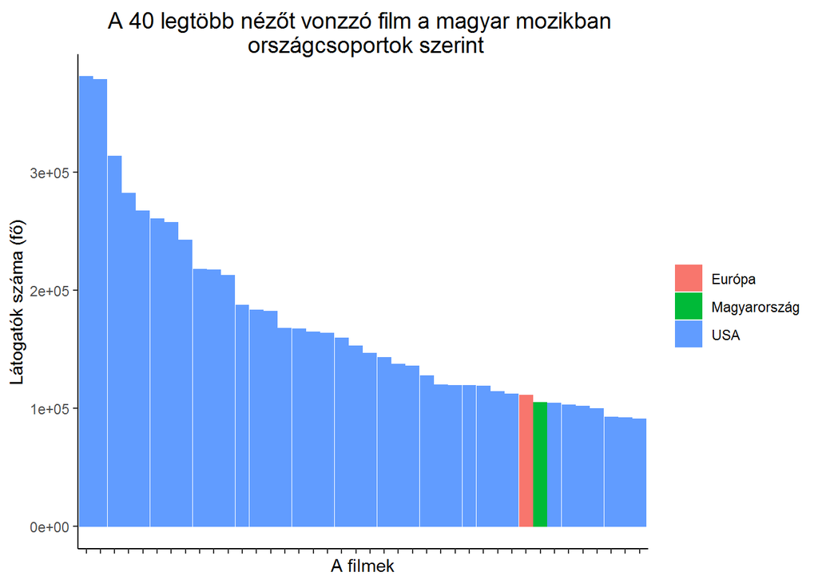

```r
#Nagyon súlyos ábrák az amerikai dominanciáról
ggplot(top40, aes(x = reorder(top40$`Film címe`, -top40$`Látogatók száma (fő)`), y = top40$`Látogatók száma (fő)`,
                  col = top40$Orszagcsoport, fill = top40$Orszagcsoport)) +
                         geom_bar(stat = "identity") +
                         ggtitle(label = "A 40 legtöbb nézőt vonzzó film a magyar mozikban \n országcsoportok szerint",) +
                         xlab(label = "A filmek") +
                         ylab(label = "Látogatók száma (fő)") +
                         mytheme() +
                         theme(legend.title = element_blank(),
                               axis.text.x = element_blank())
```

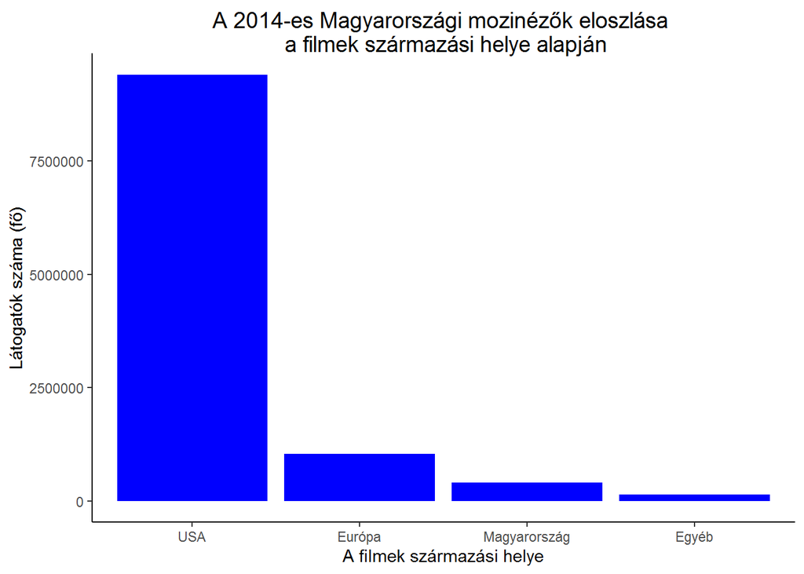

```r
ggplot(data, aes(x = data$Orszagcsoport, y = data$`Látogatók száma (fő)`)) +
                         geom_bar(stat = "identity", fill = "blue") +
                         scale_x_discrete(limits = c("USA", "Európa", "Magyarország", "Egyéb")) +
                         ggtitle("A 2014-es Magyarországi mozinézők eloszlása \n a filmek származási helye alapján") +
                         xlab("A filmek származási helye") +
                         ylab("Látogatók száma (fő)") +
                         mytheme()
```

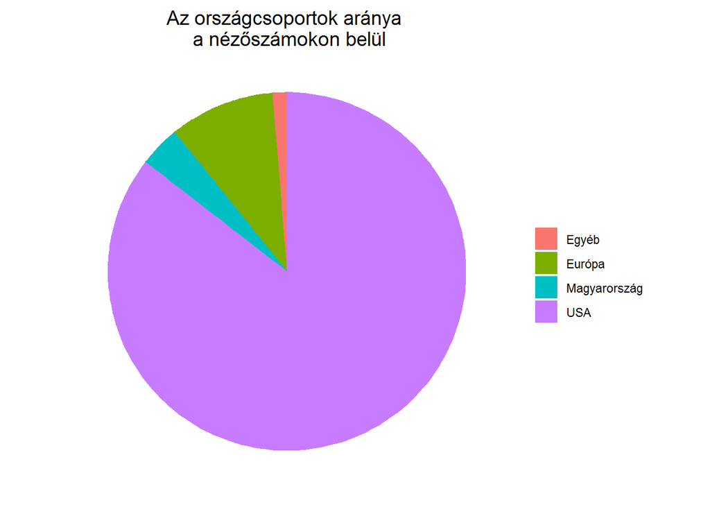

```r
ggplot(data, aes(x = 1, y = data$`Látogatók száma (fő)`, fill = data$Orszagcsoport)) +
                        geom_bar(stat = "identity") +
                        coord_polar(theta = "y") +
                        ggtitle(label = "Az országcsoportok aránya \n a nézőszámokon belül",) +
                        xlab(label = "A film bemutatójának időpontja") +
                        ylab(label = "Előadásszám") +
                        mytheme() +
                        theme(legend.title = element_blank(),
                              axis.title = element_blank(),
                              axis.line = element_blank(),
                              axis.text = element_blank(),
                              axis.ticks = element_blank())
```

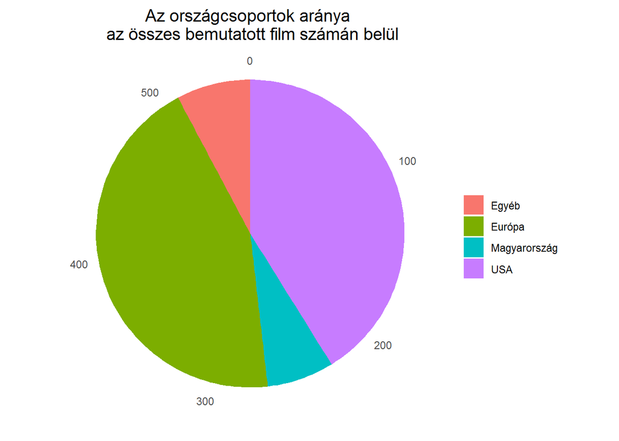

```r
ggplot(data, aes(x = 1, fill = data$Orszagcsoport)) +
                        geom_bar() +
                        coord_polar(theta = "y") +
                        ggtitle(label = "Az országcsoportok aránya \n az összes bemutatott film számán belül") +
                        mytheme() +
                        theme(legend.title = element_blank(),
                              axis.title = element_blank(),
                              axis.line = element_blank(),
                              axis.text.y = element_blank(),
                              axis.ticks = element_blank())
```

## Melyik forgalmazó becsül a legpontosabban?

A dolgozatom fő kérdése az, hogy melyik magyarországi filmforgalmazó becsli a legpontosabban a a filmjei iránti érdeklődést. Ezt két dologból lehet megállapítani. Még mielőtt a film kijönne a mozikba, a forgalmazó kópiákat készít róla, amelyeket majd a mozik vetíteni tudnak. Ezek számáról tartalmaz is adatot a táblázatom. Majd ehhez képest lesz valamekkora érdeklődés a film iránt, aminek a legjobb mérője a vetítések száma, hiszen amíg van érdeklődés rá, a filmeket műsorra tűzik. Azonban nem elég megnézni a kópiszám/vetítésszám arányt, mert az torzíthat a filmek mérete szerint. Hiszen egy plázában vagy egy vidéki városban nem kell több kópia, ha egy kicsit nagyobb az érdeklődés, csak a meglévőt többször játsszák. Az érdeklődés csökkenésével is nem lehet lefaragni a kópiaszámból egy idő után, egy darab minimum kell ha egyáltalán játszani szeretnék.

Mindezekből kifolyólag nem alkalmas egy sima lineáris modellt alkamazni, amihez a különböző forgalmazók becslési teljesítményét lehet mérni. E helyett egy olyan vonalra van szükség, ami a lehető legjobban kifejezni, hogy hány kópiához mennyi az elvárható előadászsám.

Ezt az órán tanult Empirical loss minimaliser módszerével vizsgáltam meg.

Azonban fontos előre jelezni, hogy az eredmény egyajta piaci átlagot hoz majd, ki és ehhez képest lehet csak kijelenteni, hogy valami alul- vagy felül lett becsülve. A piaci átlagot ráadásul maguk a forgalmazók is befolyásolják, ami felveti az endogenitás problémáját.

Az adatot 2 véletlenszerű csoportra bontottam, train és test csoportokra. A train csoport segíségével egy polinomiális becslést végeztem el, így kijött egy vonal, ami jó közelítése a kópiaszám-előadásszám összefüggésének. Ezt követően a test csoporttal összevetettem ezt, és kiszámoltam az MSE értékét. Megtettem ezt 1 és 12 között minden lehetséges polinpmfokra, hogy megtaláljam, hanyad fokú polinom becsli a legpontosabban a test adataimat.

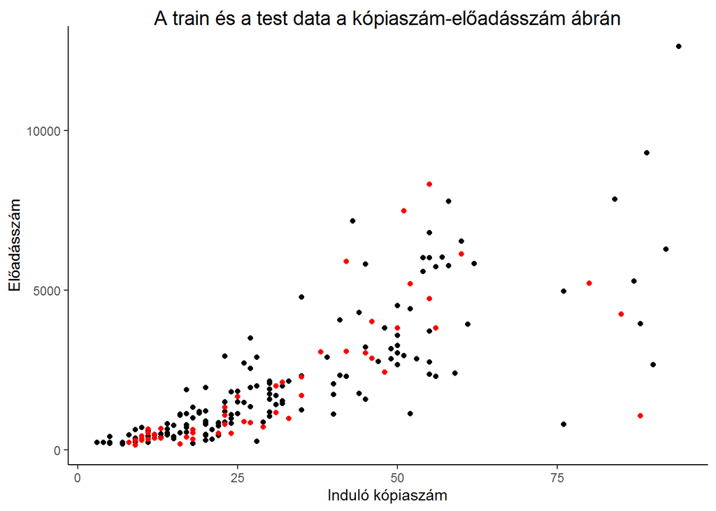

```r
#Az adat elosztása trainra és testre, majd kirajzolás

mintanagysag <- floor(0.75 * nrow(top14))
set.seed(511)
train_ind <- sample(seq_len(nrow(top14)), size = mintanagysag)
train <- top14[train_ind, ]
test <- top14[-train_ind, ]

ggplot(train, aes(x = train$`Induló összes kópiaszám`, y = train$`Előadás-szám`)) +
  geom_point() +
  geom_point(data = test, aes(x = test$`Induló összes kópiaszám`, y = test$`Előadás-szám`), color = "red") +
  ggtitle(label = "A train és a test data a kópiaszám-előadásszám ábrán",) +
  xlab(label = "Induló kópiaszám") +
  ylab(label = "Előadásszám") +
  mytheme()
```

```r
#for ciklus a legjobb polinom kiválasztására

msetabla <- list()

for (i in 1:12) {

x <- train$`Induló összes kópiaszám`
y <- train$`Előadás-szám`
fit <- lm(y~poly(x, i, raw = T))
b<-coef(fit)
xfit <- seq(min(x), max(x))
yfit <- b[1] + poly(xfit,i,raw=T) %*% b[-1]
vonal <- data.frame(xfit, yfit)

bu <- vonal$xfit[1]-1
testxmodositott <- test$`Induló összes kópiaszám`-bu
mse <- mean((test$`Előadás-szám` - vonal$yfit[testxmodositott])^2)
msetabla[[i]] <- mse
}

msetabla <- do.call(rbind, msetabla)
minpolyseged <- min(msetabla)
minpoly <- which(apply(msetabla, 1, function(r) any(r == c(minpolyseged))))
minpoly
```

```
## [1] 8
```

Miután kijött, hogy hányad fokú polinom becsli a legjobban a tesztadatot, ezt a polinomot használva szeretnék képet kapni arról, hogy a különböző forgalmazók hogyan teljesítenek. Első lépésként fixáltam a polinomot és kirajzoltam.

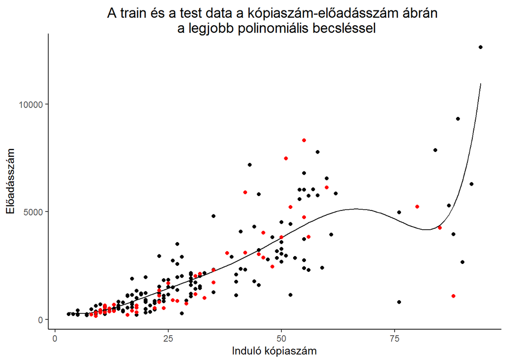

```r
# legjobb polinom használata és kirajzolása

x <- train$`Induló összes kópiaszám`
y <- train$`Előadás-szám`
fit <- lm(y~poly(x, minpoly, raw = T))
b<-coef(fit)
xfit <- seq(min(x), max(x))
yfit <- b[1] + poly(xfit,minpoly,raw=T) %*% b[-1]
vonal <- data.frame(xfit, yfit)

ggplot(train, aes(x = train$`Induló összes kópiaszám`, y = train$`Előadás-szám`)) +
  geom_point() +
  geom_line(data = vonal, aes(x = xfit, y = yfit)) +
  geom_point(data = test, aes(x = test$`Induló összes kópiaszám`, y = test$`Előadás-szám`), color = "red") +
  ggtitle(label = "A train és a test data a kópiaszám-előadásszám ábrán \n a legjobb polinomiális becsléssel",) +
  xlab(label = "Induló kópiaszám") +
  ylab(label = "Előadásszám") +
  mytheme()
```

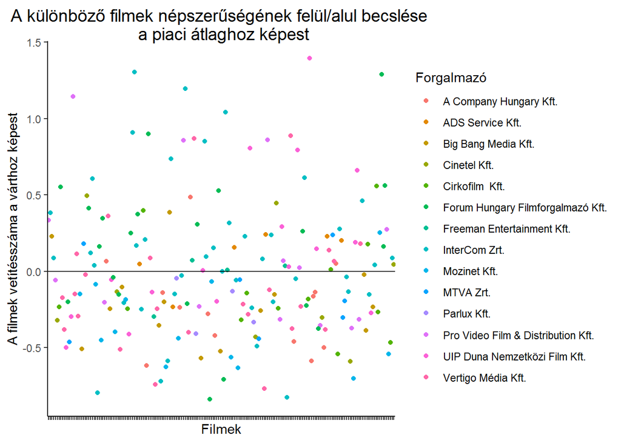

```r
#először top14-nek egy új oszlop, hogy mennyinek kéne lennie az előadászámnak a vonal alapján
kellettvolna <- function(kl) {
  kl2 <- kl-bu
  kl3 <- vonal$yfit[kl2]
  return(kl3)
}

top142 <- top14
top142$eloadaskellettvolna <- kellettvolna(top142$`Induló összes kópiaszám`)
top142$kulonbseg <- ((top142$`Előadás-szám` - top142$eloadaskellettvolna)/top142$eloadaskellettvolna)

#plotok jönnek
ggplot(top142, aes(x = top142$`Film címe`, y = top142$kulonbseg, col = `Forgalmazó`)) +
  geom_point() +
  geom_hline(yintercept = 0, alpha = 0.8) +
  ggtitle(label = "A különböző filmek népszerűségének felül/alul becslése \n a piaci átlaghoz képest",) +
  xlab(label = "Filmek") +
  ylab(label = "A filmek vetítésszáma a várthoz képest") +
  mytheme() +
  theme(axis.text.x = element_blank())
```

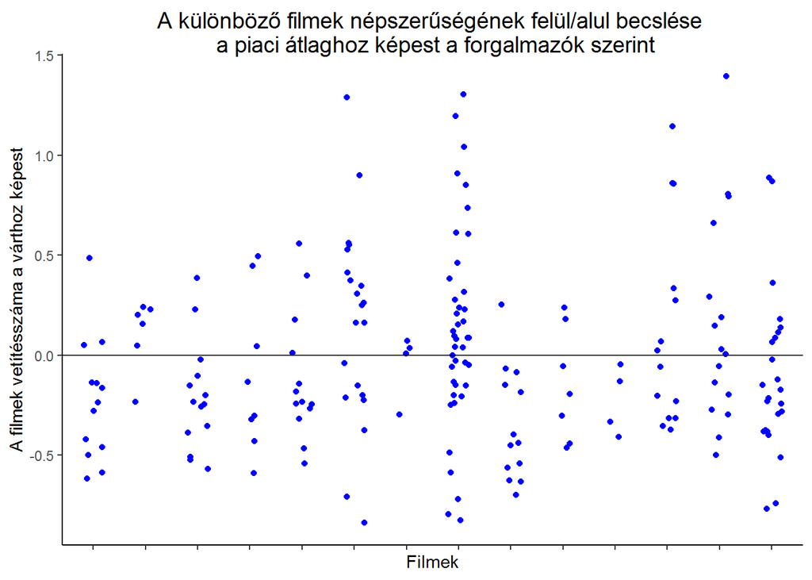

```r
ggplot(top142, aes(x = top142$`Forgalmazó`, y = top142$kulonbseg)) +
  geom_jitter(width = 0.2, color = "blue") +
  geom_hline(yintercept = 0, alpha = 0.8) +
  ggtitle(label = "A különböző filmek népszerűségének felül/alul becslése \n a piaci átlaghoz képest a forgalmazók szerint",) +
  xlab(label = "Filmek") +
  ylab(label = "A filmek vetítésszáma a várthoz képest") +
  mytheme()+
  theme(axis.text.x = element_blank())
```

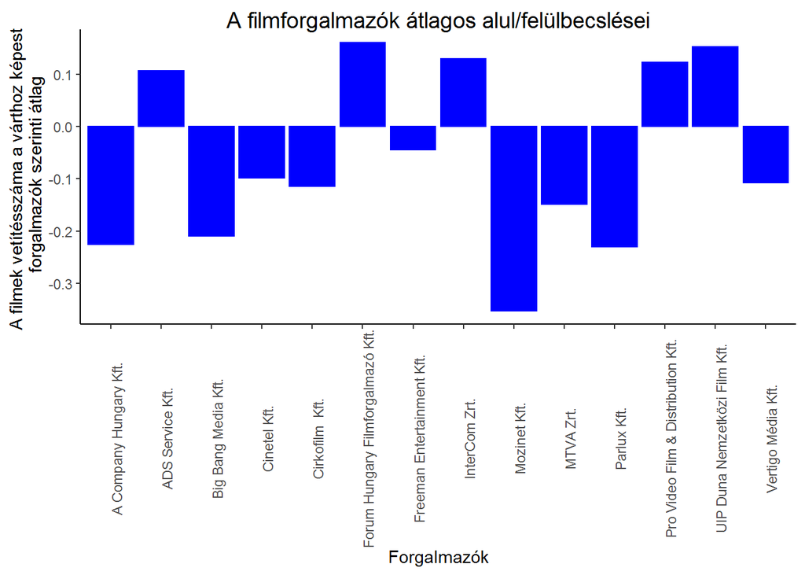

```r
sdsum <- top142 %>%
    group_by(`Forgalmazó`) %>%
    summarise(mean_becsles = mean(kulonbseg),
              sd_becsles = sd(kulonbseg),
              darab_becsles = n(),
              SE_becsles = sd(kulonbseg)/sqrt(n()))

sdsum$min <- (sdsum$mean_becsles - sdsum$sd_becsles)
sdsum$max <- (sdsum$mean_becsles + sdsum$sd_becsles)

ggplot(sdsum, aes(x = sdsum$`Forgalmazó`, y = sdsum$mean_becsles)) +
     geom_bar(stat = "identity", color = "blue", fill = "blue") +
     ggtitle(label = "A filmforgalmazók átlagos alul/felülbecslései",) +
     xlab(label = "Forgalmazók") +
     ylab(label = "A filmek vetítésszáma a várthoz képest \n forgalmazók szerinti átlag") +
     mytheme() +
     theme(axis.text.x = element_text(angle = 90))
```

[figure not shown]

```r
ggplot(sdsum, aes(x = sdsum$`Forgalmazó`, y = sdsum$mean_becsles)) +
     geom_point(size = 2.5, color = "red") +
     geom_linerange(ymin = sdsum$min, ymax = sdsum$max, size = 2.5, alpha = 0.4, color = "blue") +
     scale_y_continuous(limits = c(-1, 1)) +
     ggtitle(label = "A filmforgalmazók átlagos alul/felülbecslései, és standard hibájuk",) +
     xlab(label = "Forgalmazók") +
     ylab(label = "A filmek vetítésszáma a várthoz képest \n forgalmazók szerinti átlag, és standard hibájuk") +
     mytheme() +
     theme(axis.text.x = element_text(angle = 90))
```

Összsségében megállapítható, hogy talán a kevés adat miatt, mindenesetre a forgalmazók mind viszonylag széles spektumon mozogtak becslési hibáikat tekintve. A legpontosabb a Frrmen Entratainment Kft volt közülük. A leginkább hajlamos túlbecsülni a vetítéseket a MOzinet Kft volt, az alulbecslésre a leghajlamosabb pedig a Forum hungary Kft.